# Homework: Functions

1. Write a greeting function that says “good morning”, “good afternoon”, or “good evening”, depending on the time of day.

```r
greet()
```

```
## [1] "good evening"
```

```r
greet("6:05")
```

```
## [1] "good morning"
```

```r
greet("12:13")
```

```
## [1] "good afternoon"
```

```r
greet("17:20")
```

```
## [1] "good evening"
```

2. Write an algorithm for the following tasks. If the number is divisible by three, it returns “fizz”. If it’s divisible by five it returns “buzz”. If it’s divisible by three and five, it returns “fizzbuzz”. Otherwise, it returns the number. Please write a R function to implement this algorithm. The function takes a **vector** as input and returns a corresponding vector.

```r
x <- c(1:15)
Fizzbuzz_1(x)
```

```
##  [1] "1"        "2"        "fizz"     "4"        "buzz"     "fizz"
##  [7] "7"        "8"        "fizz"     "buzz"     "11"       "fizz"
## [13] "13"       "14"       "fizzbuzz"
```

3. Based on the probability mass function of a Poisson random variable as shown below, write a R function to compute the mean and variance with given rate parameter $\lambda$.
   $$P(X=x)=\frac{e^{-\lambda} \lambda^x}{x!},x=0,1,2,...$$
4. Create a function that given a string  
   info=‘NAME: Lee /COUNTRY:Taiwan /EMAIL: cili@ncku.edu.tw’  
   return a matrix.

```r
info='NAME: Lee /COUNTRY:Taiwan /EMAIL: cili@ncku.edu.tw'
Myinfo(info)
```

```
##      [,1]      [,2]
## [1,] "NAME"    " Lee "
## [2,] "COUNTRY" "Taiwan "
## [3,] "EMAIL"   " cili@ncku.edu.tw"
```

4. Write a R function to find the nth lowest/highest value of a vector. The user can specify the argument for finding the lowest or highest value.

```r
x <- c(1:10)
x
```

```
##  [1]  1  2  3  4  5  6  7  8  9 10
```

```r
FindNum(x, location = 2, highest = F)
```

```
## [1] 2
```

5. Write a function that can fill the area under curve (the standard normal density) for a given value $x \in (-3, 3)$ on the x-axis. The user can specify the following options:
   1. upper-tail or lower-tail
   2. the value on the x-axis

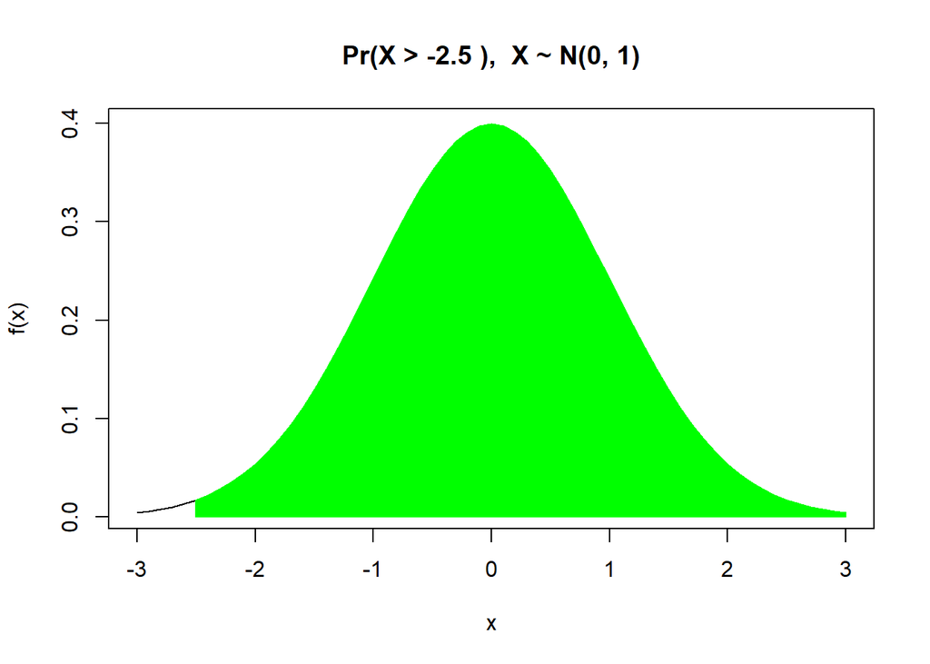

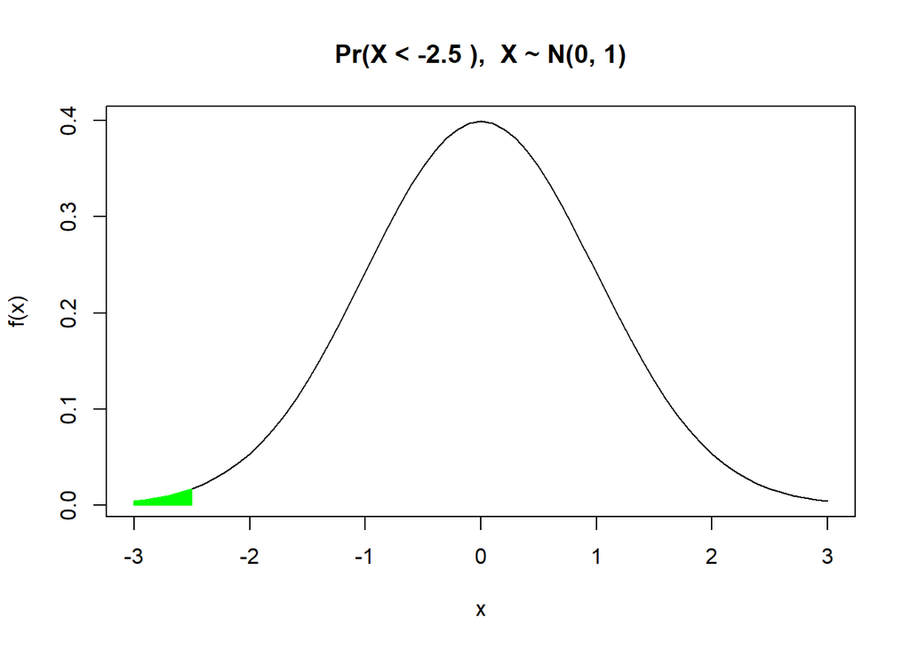

6. Use a while loop to simulate one stock price path starting at 100 and random normally distributed jump with mean 0 and standard deviation of 1 each period. How long does it take to reach above 150 or below 50? Write a R code to implement it. The value of the standard deviation can be specified by the user or used with default value of 1. The function produces a graph as shown below.

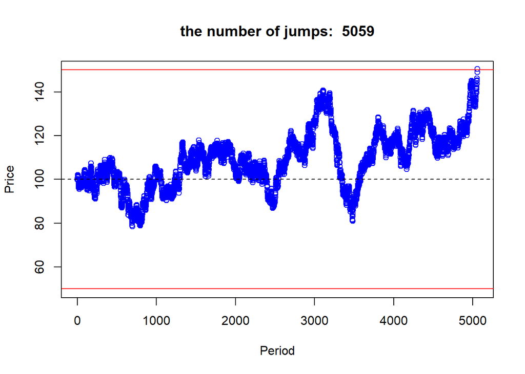

```r
Jumps(sd = 0.5)
```

```r
# hints: rnorm(1, mean = 0, sd = 1)
```

7. Write a R code to implement the Newton’s method for finding the roots of the equation. Please define all necessary input arguments and the function returns the roots and the plot of the equation.